# Messing with

- Classes
- Constructors (Parameterised, Non Param, Copy Constructors) - Overload costructors.

  Copy Constructors works the same as "by Reference", i.e. alias, but its must be an independent copy. So if the one copy is changed, the other copy should not change.

  Not well explained in notes: Here is the jist of it: If you have a pointer in one, that pointer of say r1, should not point to the same address as your copy, say r2. That is if r1 values should change.

  This only applies where you have defined a pointer in r1. Normal data types does not suffer this problem.
- Deep copy constructor solve the above problem.

  By defining a pointer in HEAP solves the problem, when dealing with pointers.
- Type of Functions (Constructors, Mutators, Accessors, Facilitators, Enquiry, Destructors)
- Scope Resolution Operator
- Difference Struct and Classes

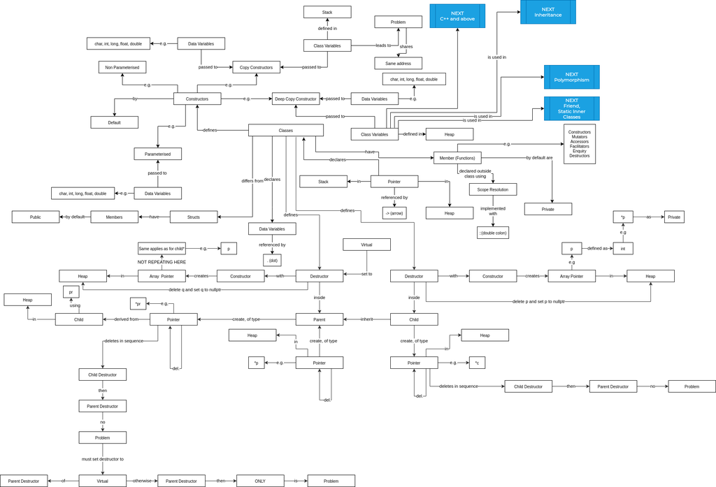

```python
#include <iostream>
#include <climits>
#include <math.h>
#define INSERTION_OPERATOR operator<<
#define EXTRACTION_OPERATOR operator>>
#define ADDITION_OPERATOR operator+
using namespace std;
```

## Definition of Class

```python
class Rectangle{
public:
    int len;
    int bth;
    int *pp;
public:
    Rectangle(){
        len=100;
        bth=100;
    }

    Rectangle(int a, int b){
        len=a;
        bth=b;
    }

    //Copy Constructor
    Rectangle(Rectangle &r1){
        len=r1.len;
        bth=r1.bth;
        pp=r1.pp;
    }

    //Deep Copy Constructor
    Rectangle(Rectangle &r1, int n){
        len=r1.len;
        bth=r1.bth;
        pp=new int [n];
    }

    int area(){
        return len * bth;
    }
    int getLen(){
        return len;
    }

    int getBth(){
        return bth;
    }

    int GetPeri(){}

}
```

```python
int Rectangle::GetPeri(){
    return 2 *(len + bth);
}
```

```python
Rectangle r1;


//no assigning of values
cout<<"Length:"<<r1.getLen()<<endl;
cout<<"Breath:"<<r1.getBth()<<endl;
cout<<"Area:"<<r1.area()<<endl;

//assigning of values
r1.len = 10;
r1.bth = 20;

cout<<"Area:"<<r1.area()<<endl;
```

```
Length:100
Breath:100
Area:10000
Area:200
```

## Pointer to class (in Stack)

Using --> Dereference structure pointer arrow.

```python
Rectangle *p;

p = &r1;

p->len = 30;
p->bth = 40;

cout<<"Area:"<<p->area()<<endl;
```

```
Area:1200
```

## Pointer to class (in Heap)

If you do DECLARATION and INITIALISATION at same time:

```
Rectangle *p_1=new Rectangle();
```

```python
Rectangle *p_1;

p_1 = new Rectangle;

p_1->len = 50;
p_1->bth = 40;

cout<<"Area:"<<p_1->area()<<endl;

delete p_1;
```

```
Area:2000
```

## Copy Constructor in Action

```python
Rectangle r_1;

int A[5] ={4,5};

r_1.len = 70;
r_1.bth = 60;
r_1.pp = A;

Rectangle r_2(r_1);

cout<<"Area:"<<r_1.area()<<endl;
cout<<"Area:"<<r_2.area()<<endl;
```

```
Area:4200
Area:4200
```

#### Update r1 and r2. no problem so far with Copy Constructor

```python
r_1.len = 70;
r_1.bth = 60;

r_2.len = 7;
r_2.bth = 6;

cout<<"Area:"<<r_1.area()<<endl;
cout<<"Area:"<<r_2.area()<<endl;
```

```
Area:4200
Area:42
```

#### Shares different adddresses for pointer - not problem so far

```python
cout<<"Area:"<<&r_1.pp<<endl;
cout<<"Area:"<<&r_2.pp<<endl;
```

```
Area:0x7f2a126c0070
Area:0x7f2a126c0088
```

#### Now we get problems with pointers (defined in stack - normal pointers)

#### That is changing r2, affects r1 - This is PROBLEM of Copy Constructor.

#### Shares the same address space (for items)

```python
r_1.pp[0]=10;
r_2.pp[0]=20;
cout<<"Area:"<<&r_1.pp[0]<<endl;
cout<<"Area:"<<&r_2.pp[0]<<endl;
cout<<"Area:"<<r_1.pp[0]<<endl;
cout<<"Area:"<<r_2.pp[0]<<endl;
```

```
Area:0x7f2a126c0050
Area:0x7f2a126c0050
Area:20
Area:20
```

## Deep Copy Constructor in Action

```python
Rectangle r_3;

int A_1[5] ={4,5};

r_3.len = 70;
r_3.bth = 60;
r_3.pp = A_1;

Rectangle r_4(r_3,5);

cout<<"Area:"<<r_3.area()<<endl;
cout<<"Area:"<<r_4.area()<<endl;
```

```
Area:4200
Area:4200
```

#### Update r1 and r2. no problem (as indicated above)

```python
r_3.len = 70;
r_3.bth = 60;

r_4.len = 7;
r_4.bth = 6;


cout<<"Area:"<<r_3.area()<<endl;
cout<<"Area:"<<r_4.area()<<endl;
```

```
Area:4200
Area:42
```

#### Check in class definition above, how we solved the issues

#### NOW - Each one has its own address space

```python
r_3.pp[0]=10;
r_4.pp[0]=20;
cout<<"Area:"<<&r_3.pp[0]<<endl;
cout<<"Area:"<<&r_4.pp[0]<<endl;
cout<<"Area:"<<r_3.pp[0]<<endl;
cout<<"Area:"<<r_4.pp[0]<<endl;
```

```
Area:0x7f2a126c00a0
Area:0x55bd52464000
Area:10
Area:20
```